# FigureYa10chromosomeV2_update

**Author(s)**: Zhaodong Hao  
**Reviewer(s)**: Ying Ge, Yijing Chen **Date**: 2025-12-03

## 1 Academic Citation

If you use this code in your work or research, we kindly request that you cite our publication:

Xiaofan Lu, et al. (2025). FigureYa: A Standardized Visualization Framework for Enhancing Biomedical Data Interpretation and Research Efficiency. iMetaMed. 1(1) https://doi.org/10.1002/imm3.70005

To cite package ‘RIdeogram’ in publications use:

Hao Z, Lv D, Ge Y, Shi J, Weijers D, Yu G, Chen J. 2020. RIdeogram: drawing SVG graphics to visualize and map genome-wide data on the idiograms. PeerJ Comput. Sci. 6:e251 http://doi.org/10.7717/peerj-cs.251

## 2 需求描述 Requirement Description

用R代码画出paper里的直的染色体分布图

Use R code to draw the straight chromosome distribution map in paper

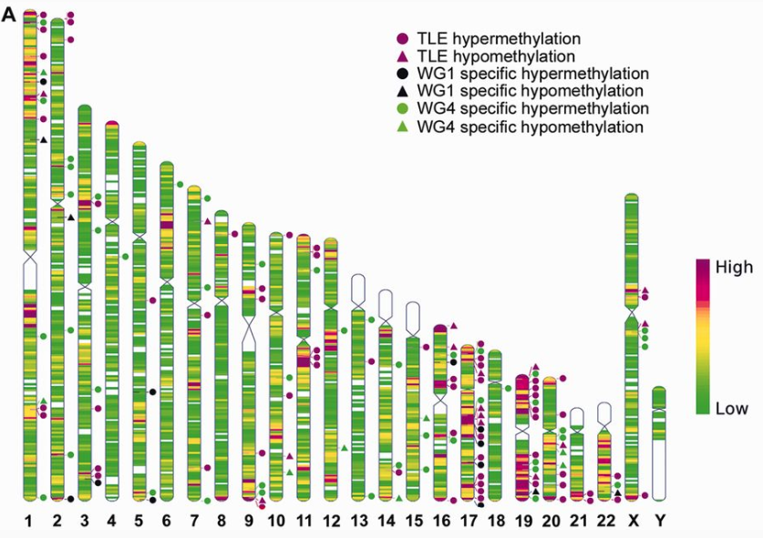

Fromhttps://academic.oup.com/brain/article/138/3/616/333368

## 3 应用场景 Application Scenario

差异表达基因（RNA-seq）、开放染色质（DNase/ATAC-seq）、CTCF结合位点（ChIP-seq）、突变位点（WGS）或DNA甲基化（WGBS）在染色体上的分布，或者只是画Ideogram

Distribution of differentially expressed genes (RNA-seq), open chromatin (DNase/ATAC-seq), CTCF binding sites (ChIP-seq), mutation sites (WGS), or DNA methylation (WGBS) on chromosomes, or just drawing Ideograms

## 4 环境设置 Environment Setting

```r
source("install_dependencies.R")
```

[output not shown]

```r
library(RIdeogram)
Sys.setenv(LANGUAGE = "en") #显示英文报错信息 display English error messages
options(stringsAsFactors = FALSE) #禁止chr转成factor prohibit the conversion of chr to factor
```

## 5 输入文件 Input file

三个输入文件，其中第一个文件必需提供，第二和第三个文件非必需：

- karyotype.csv，用于画染色体轮廓。包含五列：第一列为染色体名，第二、三列为染色体的起始和终止点。如果能提供着丝粒的开始和结束位置，就给出第四列（起始）和第五列（终止），如果着丝粒位置未知，就只给前三列。0-based基因组坐标(以0-based开始、1-based结束)。
- easy_input_heatmap.csv，用来绘制染色体heatmap。包含四列，第一列染色体名，第二、三列为染色体上的位置，第四列为相应位置上的值。例如差异基因的log2foldchange、甲基化水平等。
- easy_input_mark.csv，如果想画染色体旁边的形状标记，就要提供这个文件。包含六列，第一列type，第二列形状（只支持三种形状：box正方形、triangle三角形和circle圆。如果需要标记的特征超过3种，就用第六列里的颜色区分吧，例如红色的三角形，蓝色的三角形等），第三列染色体，第四、五列染色体上的位置，第六列颜色。**注意：**同一type对应的颜色一致。

Three input files, of which the first is required and the second and third are not required:

- karyotype.csv, used for drawing chromosome outlines. It contains five columns: the first column is the chromosome name, and the second and third columns are the start and end points of the chromosome. If the start and end positions of the centromere are available, the fourth column (start) and the fifth column (end) are included; if the centromere position is unknown, only the first three columns are provided. 0-based genomic coordinates (start with 0-based and end with 1-based).
- easy_input_heatmap.csv, used for drawing chromosome heatmaps. It contains four columns: the first column is the chromosome name, the second and third columns are the positions on the chromosome, and the fourth column is the value at the corresponding position, such as the log2 fold change of differential genes, methylation levels, etc.
- easy_input_mark.csv: If you want to draw shape markers next to the chromosomes, you need to provide this file. It contains six columns: the first column is the type, the second column is the shape (only three shapes are supported: box, triangle, and circle. If the features you need to mark exceed three types, use the color in the sixth column to differentiate, such as red triangles, blue triangles, etc.), the third column is the chromosome, the fourth and fifth columns are the positions on the chromosome, and the sixth column is the color. **Note:** The color corresponding to the same type should be consistent.

```r
# 染色体长度、中心粒位置
# chromosome length, centromere position
karyotype <- read.csv("karyotype.csv")
karyotype
```

```
##    Chr Start       End  CE_start    CE_end
## 1    1     0 248956422 122026459 124932724
## 2    2     0 242193529  92188145  94090557
## 3    3     0 198295559  90772458  93655574
## 4    4     0 190214555  49712061  51743951
## 5    5     0 181538259  46485900  50059807
## 6    6     0 170805979  58553888  59829934
## 7    7     0 159345973  58169653  61528020
## 8    8     0 145138636  44033744  45877265
## 9    9     0 138394717  43389635  45518558
## 10  10     0 133797422  39686682  41593521
## 11  11     0 135086622  51078348  54425074
## 12  12     0 133275309  34769407  37185252
## 13  13     0 114364328  16000000  18051248
## 14  14     0 107043718  16000000  18173523
## 15  15     0 101991189  17083673  19725254
## 16  16     0  90338345  36311158  38265669
## 17  17     0  83257441  22813679  26616164
## 18  18     0  80373285  15460899  20861206
## 19  19     0  58617616  24498980  27190874
## 20  20     0  64444167  26436232  30038348
## 21  21     0  46709983  10864560  12915808
## 22  22     0  50818468  12954788  15054318
## 23   X     0 156040895  58605579  62412542
## 24   Y     0  57227415  10316944  10544039
```

```r
# 染色体上的heatmap
# heatmap on chromosomes
gene_density <- read.csv("easy_input_heatmap.csv")
head(gene_density)
```

```
##   Chr   Start     End Value
## 1   1       1 1000000    65
## 2   1 1000000 2000000    76
## 3   1 2000000 3000000    35
## 4   1 3000000 4000000    30
## 5   1 4000000 5000000    10
## 6   1 5000000 6000000    10
```

```r
# 染色体旁边的形状标记
# shape markers next to chromosomes
Random_RNAs_500 <- read.csv("easy_input_mark.csv")
head(Random_RNAs_500)
```

```
##    Type    Shape Chr    Start      End  color
## 1  tRNA   circle   6 69204486 69204568 6a3d9a
## 2  rRNA      box   3 68882967 68883091 33a02c
## 3  rRNA      box   5 55777469 55777587 33a02c
## 4  rRNA      box  21 25202207 25202315 33a02c
## 5 miRNA triangle   1 86357632 86357687 ff7f00
## 6 miRNA triangle  11 74399237 74399333 ff7f00
```

## 6 开始画图 Start Drawing

```r
ideogram(karyotype = karyotype,

         #如果没提供easy_input_heatmap.csv，就在下面两行前面加#
         #If easy_input_heatmap.csv is not provided, precede the following two lines with#
         overlaid = gene_density,
         #染色体上heatmap的配色
         #color matching of heatmap on chromosomes
         colorset1 = c("forestgreen", "gold", "deeppink3"),

         #如果没提供easy_input_mark.csv，就在下面这行前面加#
         #If easy_input_mark.csv is not provided, prefix the following line with#
         label = Random_RNAs_500,
         label_type = "marker",

         #染色体宽度，默认170
         #chromosome width, default 170
         width = 180, #注意：太宽会跑出画布外面 Note: If it's too wide, it will extend beyond the canvas

         #图例的位置
         #position of legend
         Lx = 160, #图例左上角跟左边的距离 distance from the top left corner of the legend to the left side
         Ly = 20, #图例左上角跟顶端的距离 distance from the upper left corner of the legend to the top

         #输出文件
         #output file
         output = "chromosome.svg") #只支持svg格式 only svg format is supported

# 可以转成png，方便查看
# It can be converted to png for easy viewing
convertSVG("chromosome.svg", device = "png")
```

## 7 格式转换 Format conversion

运行完上面这段，当前文件夹里会生成一个“chromosome.svg”文件，是矢量图。可以用Inkscape、Illustrator等工具打开、编辑、转换成其他格式。

还可以运行下面这段把svg转成pdf或tiff、jpg、png等格式的文件

After running the above paragraph, a file “chromosome.svg” will be generated in the current folder, which is a vector image. You can use Inkscape, Illustrator and other tools to open, edit, convert to other formats.

You can also run the following paragraph to svg into pdf or tiff, jpg, png and other formats of the file

```r
#svg2pdf或svg2tiff、svg2jpg、svg2png
#svg2pdf or svg2tiff、svg2jpg、svg2png
svg2pdf("chromosome.svg",
        width = 12, height = 8, #画布大小 canvas size
        dpi = 300)
```

[figure not shown]

## 8 附：karyotype.csv文件的准备 Appendix: Preparation of karyotype.csv file

这里提供两种两种方法，二选一即可。 Two methods are provided here, choose one.

## 9 方法一：用rtracklayer实现 Method 1: Using rtracklayer

适合处理复杂的基因组数据 Suitable for processing complex genomic data

```r
library(rtracklayer)
library(dplyr)

# 读取 GTF 文件 \ Read GTF file
gtf <- import("your_file.gtf")  # 使用 rtracklayer 导入 GTF 文件 \ Use rtracklayer to import GTF file

# 提取染色体信息 \ Extract chromosome information
karyotype <- gtf %>%
  as.data.frame() %>%  # 转换为数据框 \ Convert to data frame
  filter(type == "chromosome") %>%  # 筛选染色体信息 \ Filter chromosome information
  select(seqnames, start, end) %>%  # 提取染色体名称、起始位置和终止位置 \ Extract chromosome name, start position, and end position
  rename(Chromosome = seqnames, Start = start, End = end) %>%
  mutate(Centromere_Start = NA, Centromere_End = NA)  # 如果没有着丝粒信息，可以填充 NA \ If centromere information is unavailable, fill with NA

# 如果有着丝粒信息，提取并合并 \ If centromere information is available, extract and merge
centromere <- gtf %>%
  as.data.frame() %>%
  filter(type == "centromere") %>%  # 筛选着丝粒信息 \ Filter centromere information
  select(seqnames, start, end) %>%
  rename(Chromosome = seqnames, Centromere_Start = start, Centromere_End = end)

karyotype <- karyotype %>%
  left_join(centromere, by = "Chromosome")

# 保存为 karyotype.csv \ Save as karyotype.csv
write.csv(karyotype, "karyotype.csv", row.names = FALSE)
```

## 10 方法二：用dplyr实现 Method 2: Using dplyr

适合结构简单的GTF文件 Suitable for simple GTF file structures

```r
library(dplyr)

# 读取 GTF 文件 \ Read GTF file
gtf <- read.table("your_file.gtf", sep = "\t", header = FALSE, stringsAsFactors = FALSE)

# 提取染色体信息 \ Extract chromosome information
karyotype <- gtf %>%
  filter(V3 == "chromosome") %>%  # 筛选染色体信息 \ Filter chromosome information
  select(V1, V4, V5) %>%         # 提取染色体名称、起始位置和终止位置 \ Extract chromosome name, start position, and end position
  rename(Chromosome = V1, Start = V4, End = V5) %>%
  mutate(Centromere_Start = NA, Centromere_End = NA)  # 如果没有着丝粒信息，可以填充 NA \ If centromere information is unavailable, fill with NA

# 如果有着丝粒信息，提取并合并 \ If centromere information is available, extract and merge
centromere <- gtf %>%
  filter(V3 == "centromere") %>%  # 筛选着丝粒信息 \ Filter centromere information
  select(V1, V4, V5) %>%
  rename(Chromosome = V1, Centromere_Start = V4, Centromere_End = V5)

karyotype <- karyotype %>%
  left_join(centromere, by = "Chromosome")

# 保存为 karyotype.csv \ Save as karyotype.csv
write.csv(karyotype, "karyotype.csv", row.names = FALSE)
```